# PS #02

Author

Boyuan Ma

[Link to GitHub](https://github.com/mab0y/Stats-506/tree/main/PS-02)

## Problem 1 - Dice Game

### a.

Version 1:

```r
  #' Function to calculate total winnings with a loop
  #'
  #' @param times a numeric scalar
  #' @return the total winnings after times of rolls
  play_dice1 <- function(times){
    total_winnings <- 0
    for (i in 1:times){
      dice <- sample(1:6, 1, replace = TRUE)
      if (dice %in% c(2, 4, 6)){
        total_winnings <- total_winnings + dice - 2
      }
      else{
        total_winnings <- total_winnings - 2
      }
    }
    return(total_winnings)
  }
```

Version 2:

```r
  #' Function to calculate total winnings with vectorized functions
  #'
  #' @param times a numeric scalar
  #' @return the total winnings after times of rolls
  play_dice2 <- function(times){
    dices <- sample(1:6, times, replace = TRUE)
    total_winnings <- sum(ifelse(dices %in% c(2,4,6), dices -2, -2))
    return(total_winnings)
  }
```

Version 3:

```r
  # Here I refer to https://stackoverflow.com/questions/39176032/extracting-elements-from-a-table-in-r.
  # I found that table names are str. I can turn them to integer to test the divisiblity or use them directly to index the value

  #' Function to calculate total winnings with table of die rolls
  #'
  #' @param times a numeric scalar
  #' @return the total winnings after times of rolls
  play_dice3 <- function(times){
    total_winnings <- 0
    dices_table <- table(sample(1:6, times, replace = TRUE))
    for (i in names(dices_table)){
      name_integer = as.integer(i)
      if (name_integer %% 2 == 0){
        total_winnings <- total_winnings + dices_table[[i]] * (name_integer -2)
      }
      else{
        total_winnings <- total_winnings - dices_table[[i]] * 2
      }
    }
    return(total_winnings)
  }
```

Version 4:

```r
  #' Function to calculate total winnings with lapply function
  #'
  #' @param times a numeric scalar
  #' @return the total winnings after times of rolls
  play_dice4 <- function(times){
    dices <- sample(1:6, times, replace = TRUE)
    winnings <- sapply(dices, function(dice){
      if (dice %in% c(2,4,6)){
        return(dice-2)
      }
      else{
        return(-2)
      }
    })
    return(sum(winnings))
  }
```

### b.

Version 1:

```r
  play_dice1(3)
```

```
[1] -6
```

```r
  play_dice1(3000)
```

```
[1] 46
```

```r
  play_dice1(3)
```

```
[1] -4
```

```r
  play_dice1(3000)
```

```
[1] -100
```

```r
  play_dice2(3)
```

```
[1] 0
```

```r
  play_dice2(3000)
```

```
[1] -94
```

```r
  play_dice2(3)
```

```
[1] -6
```

```r
  play_dice2(3000)
```

```
[1] 184
```

### c.

Version 1:

```r
  set.seed(42)
  play_dice1(3)
```

```
[1] -6
```

```r
  play_dice1(3000)
```

```
[1] -116
```

Version 2:

```r
  set.seed(42)
  play_dice2(3)
```

```
[1] -6
```

```r
  play_dice2(3000)
```

```
[1] -116
```

Version 3:

```r
  set.seed(42)
  play_dice3(3)
```

```
[1] -6
```

```r
  play_dice3(3000)
```

```
[1] -116
```

Version 4:

```r
  set.seed(42)
  play_dice4(3)
```

```
[1] -6
```

```r
  play_dice4(3000)
```

```
[1] -116
```

### d.

low input (100):

```r
  mb1<-microbenchmark(play_dice1(100))
  mb2<-microbenchmark(play_dice2(100))
  mb3<-microbenchmark(play_dice3(100))
  mb4<-microbenchmark(play_dice4(100))
  rbind(mb1,mb2,mb3,mb4)
```

```
Unit: microseconds
            expr   min     lq    mean median     uq    max neval
 play_dice1(100) 465.1 535.20 727.682  554.9 863.55 4310.4   100
 play_dice2(100)  18.3  19.35  26.621   22.3  29.85   65.2   100
 play_dice3(100)  68.5  99.60 137.240  124.9 164.05  518.4   100
 play_dice4(100) 141.1 144.90 153.284  147.3 154.75  289.5   100
```

large input (10000):

```r
  mb1<-microbenchmark(play_dice1(10000))
  mb2<-microbenchmark(play_dice2(10000))
  mb3<-microbenchmark(play_dice3(10000))
  mb4<-microbenchmark(play_dice4(10000))
  rbind(mb1,mb2,mb3,mb4)
```

```
Unit: microseconds
              expr     min       lq      mean   median       uq      max neval
 play_dice1(10000) 51150.0 54515.50 59678.098 57540.90 62708.45 109189.4   100
 play_dice2(10000)   811.0  1044.90  1504.216  1082.45  1716.30   6701.7   100
 play_dice3(10000)  1399.1  1678.55  2265.855  1741.75  2547.30  10168.9   100
 play_dice4(10000) 20657.4 22702.20 25058.514 24156.40 25894.15  40288.3   100
```

For low input, vectorized function appears to execute faster compared to other methods. Collapsing the data into table also yields efficient results. The `apply` function exhibits slightly slower performance compared to vectorized functions and table transformations, while using loops is the slowest approach.

For large input, both vectorized functions and data table transformations perform at similar speeds. The `table` function may provide a shortcut for counting the occurrences of each dice outcome, as it avoids the need to iterate over all the dice rolls. `apply` functions and looping still exhibit slower execution times.

### e.

The game is fair, with each dice having an expected winning of 0. Consequently, the total winnings remain 0, regardless of the number of dice the player selects. In this simulation, I played the game 100,000 times, varying the number of dice from 1 to 20, and calculated the average winnings for each scenario: I:

```r
for (i in 1:20){
  cat("Number of dice to roll is:", i, "The average total winning is:", mean(replicate(100000,play_dice1(i))), "\n")
}
```

```
Number of dice to roll is: 1 The average total winning is: -0.00774
Number of dice to roll is: 2 The average total winning is: 0.01574
Number of dice to roll is: 3 The average total winning is: 0.0021
Number of dice to roll is: 4 The average total winning is: -0.01566
Number of dice to roll is: 5 The average total winning is: -0.0145
Number of dice to roll is: 6 The average total winning is: 0.00372
Number of dice to roll is: 7 The average total winning is: -0.00246
Number of dice to roll is: 8 The average total winning is: 0.00394
Number of dice to roll is: 9 The average total winning is: -0.02812
Number of dice to roll is: 10 The average total winning is: 0.0174
Number of dice to roll is: 11 The average total winning is: 0.03434
Number of dice to roll is: 12 The average total winning is: 0.03232
Number of dice to roll is: 13 The average total winning is: -0.01394
Number of dice to roll is: 14 The average total winning is: 0.03828
Number of dice to roll is: 15 The average total winning is: 0.022
Number of dice to roll is: 16 The average total winning is: 0.04242
Number of dice to roll is: 17 The average total winning is: -0.02102
Number of dice to roll is: 18 The average total winning is: 0.02108
Number of dice to roll is: 19 The average total winning is: -0.00028
Number of dice to roll is: 20 The average total winning is: 0.02044
```

## Problem 2 - Linear Regression

### a.

```r
cars <- read.csv("~/cars.csv",header=TRUE)
colnames(cars) <- c("height", "length", "width", "driveline", "engine_type", "hybrid", "forward_gears", "transmission", "city_mpg","fuel_type", "highway_mpg", "classification", "id", "make", "model_year", "year", "horsepower", "torque")
```

### b.

```r
cars <- cars[which(cars$fuel_type == "Gasoline"),]
```

### c.

```r
cars$year <- as.factor(cars$year)
cars_lm <- lm(highway_mpg ~ horsepower + torque + height + length + width + year, cars)
```

```
Call:
lm(formula = highway_mpg ~ horsepower + torque + height + length +
    width + year, data = cars)

Coefficients:
(Intercept)   horsepower       torque       height       length        width
 32.2926630    0.0163556   -0.0507425    0.0099079    0.0017290   -0.0003343
   year2010     year2011     year2012
 -0.4539681    0.1711016    1.3029279
```

Controlling all three dimensions of the car and the year chosen the same, 1 increase in horsepower will increase highway MPG by 0.0163556, on average.

### d.

Choose year 2011 as input:

```r
table(cars$year)
```

```
2009 2010 2011 2012
  48 1633 1794 1116
```

Draw lines from default +/- 1 standard deviation of torque:

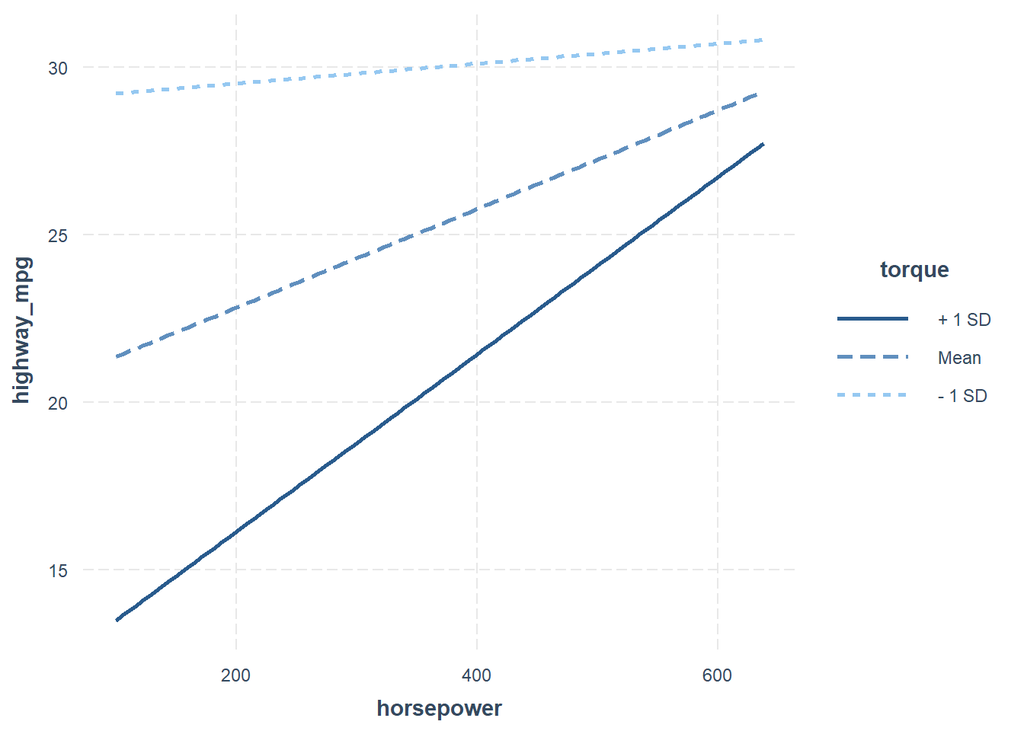

```r
cars_lm_inter <- lm(highway_mpg ~ horsepower * torque +  year, cars)
interact_plot(cars_lm_inter, pred = horsepower, modx = torque, at = list("year"=factor(2011)))
```

Or we can choose more reasonable values for torque:

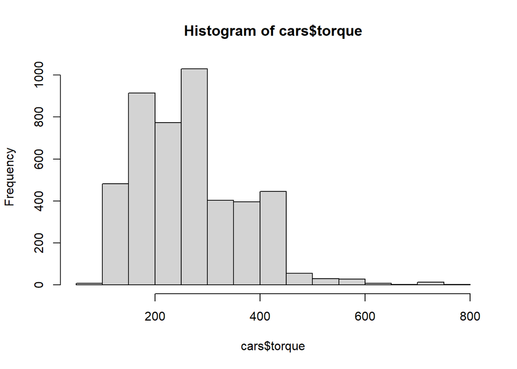

```r
hist(cars$torque)
```

```r
quantile(cars$torque)
```

```
  0%  25%  50%  75% 100%
  98  177  257  332  774
```

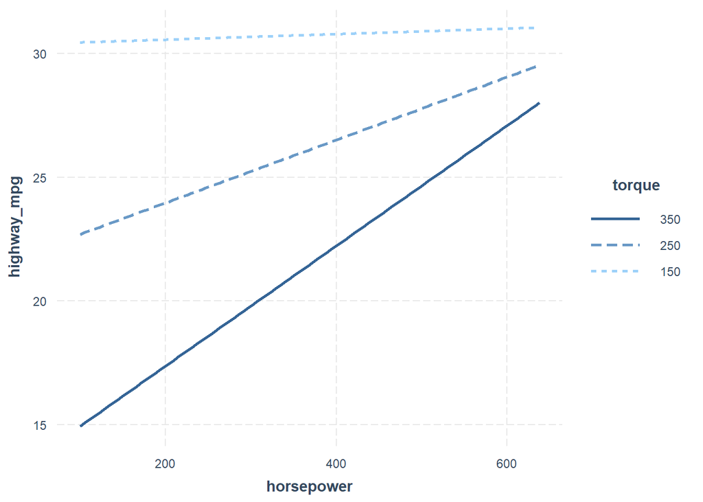

```r
interact_plot(cars_lm_inter, pred = horsepower, modx = torque, modx.values = c(150,250,350), at = list("year"=factor(2011)))
```

### e.

Add the constant column of 1, interaction term and dummy variable of year, combine them together to the design matrix:

```r
horsepower_torque<-cars$horsepower*cars$torque
year2010 <- as.numeric(cars$year == 2010)
year2011 <- as.numeric(cars$year == 2011)
year2012 <- as.numeric(cars$year == 2012)

design_matrix <- cbind(rep(1,nrow(cars)),cars[,c("horsepower","torque")],year2010,year2011,year2012,horsepower_torque)
design_matrix <- as.matrix(design_matrix)
```

Solve beta_hat:

```r
beta_hat <- solve(t(design_matrix) %*% design_matrix) %*% t(design_matrix) %*% cars$highway_mpg
```

```
                            [,1]
rep(1, nrow(cars)) 43.3673957613
horsepower         -0.0162622273
torque             -0.0891668545
year2010           -0.2522752978
year2011            0.3491989353
year2012            1.4999244802
horsepower_torque   0.0001158674
```

```
Call:
lm(formula = highway_mpg ~ horsepower * torque + year, data = cars)

Coefficients:
      (Intercept)         horsepower             torque           year2010
       43.3673958         -0.0162622         -0.0891669         -0.2522753
         year2011           year2012  horsepower:torque
        0.3491989          1.4999245          0.0001159
```

## Problem 3 - Stata

### a.

```stata
. import delimited cars.csv
(encoding automatically selected: ISO-8859-1)
(18 vars, 5,076 obs)

. rename (dimensionsheight dimensionslength dimensionswidth engineinformationdri veline engineinformationenginestatistic engineinformationenginetype engineinformationhybrid engineinformationnumberofforward engineinformationtransmission fuelinformation citympg fuelinformation fueltype fuelinformationhighwaympg identificationclassification identificationid identificationmake identificationmodelyear identificationyear v18) (height length width driveline horsepower enginetype hybrid forward_gears transmission city_mpg fuel_type highway_mpg classification id make model_year year torque)
```

### b.

```stata
. keep if fuel_type == "Gasoline"
(485 observations deleted)
```

### c.

```stata
. reg highway_mpg c.horsepower c.torque c.height c.length c.width i.year
      Source |       SS           df       MS      Number of obs   =     4,591
-------------+----------------------------------   F(8, 4582)      =    413.35
       Model |  70043.6695         8  8755.45869   Prob > F        =    0.0000
    Residual |   97055.298     4,582  21.1818634   R-squared       =    0.4192
-------------+----------------------------------   Adj R-squared   =    0.4182
       Total |  167098.968     4,590  36.4050038   Root MSE        =    4.6024

------------------------------------------------------------------------------
 highway_mpg | Coefficient  Std. err.      t    P>|t|     [95% conf. interval]
-------------+----------------------------------------------------------------
  horsepower |   .0163556   .0022772     7.18   0.000     .0118913      .02082
      torque |  -.0507425    .002203   -23.03   0.000    -.0550614   -.0464236
      height |   .0099079   .0011267     8.79   0.000      .007699    .0121168
      length |    .001729   .0008836     1.96   0.050    -3.36e-06    .0034613
       width |  -.0003343   .0009045    -0.37   0.712    -.0021075    .0014388
             |
        year |
       2010  |  -.4539681   .6768246    -0.67   0.502     -1.78087    .8729342
       2011  |   .1711016   .6757043     0.25   0.800    -1.153604    1.495808
       2012  |   1.302928   .6810076     1.91   0.056    -.0321751    2.638031
             |
       _cons |   32.29266   .7225982    44.69   0.000     30.87602     33.7093
------------------------------------------------------------------------------
Controlling all three dimensions of the car and the year chosen the same, 1 increase in horsepower will increase highway MPG by 0.0163556, on average.
```

### d.

Perfom the regression:

```stata
. reg highway_mpg c.horsepower##c.torque c.height  c.length c.width i.year

     Source |       SS           df       MS      Number of obs   =     4,591
-------------+----------------------------------   F(9, 4581)      =    480.07
       Model |  81105.8715         9  9011.76351   Prob > F        =    0.0000
    Residual |   85993.096     4,581  18.7716865   R-squared       =    0.4854
-------------+----------------------------------   Adj R-squared   =    0.4844
       Total |  167098.968     4,590  36.4050038   Root MSE        =    4.3326

-------------------------------------------------------------------------------
  highway_mpg | Coefficient  Std. err.      t    P>|t|     [95% conf. interval]
--------------+----------------------------------------------------------------
   horsepower |  -.0166633   .0025388    -6.56   0.000    -.0216406    -.011686
       torque |  -.0860593   .0025333   -33.97   0.000    -.0910257   -.0810928
              |
 c.horsepower#|
     c.torque |   .0001124   4.63e-06    24.28   0.000     .0001033    .0001214
              |
       height |   .0065604   .0010696     6.13   0.000     .0044634    .0086573
       length |   .0017767   .0008318     2.14   0.033     .0001459    .0034075
        width |  -.0011694   .0008521    -1.37   0.170      -.00284    .0005011
              |
         year |
        2010  |  -.5627858   .6371716    -0.88   0.377    -1.811949    .6863777
        2011  |   .0725356   .6361142     0.11   0.909    -1.174555    1.319626
        2012  |   1.197033   .6411085     1.87   0.062    -.0598488    2.453915
              |
        _cons |   42.18795   .7930274    53.20   0.000     40.63323    43.74266
-------------------------------------------------------------------------------
```

Calculate the mean and one standard deviation of torque to draw three lines:

```stata
. local mean_value = r(mean)

. local sd_value = r(sd)

. local mean_plus_sd = `mean_value' + `sd_value'

. local mean_minus_sd = `mean_value' - `sd_value'
```

Set year to 2011, draw the three lines with margins:

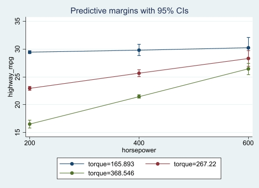

Regression Output 1

```stata
. margins,  at(horsepower=(200(200)600) torque=(`mean_minus_sd' `mean_value' `mean_plus_sd') year=2011)

Predictive margins                                       Number of obs = 4,591
Model VCE: OLS

Expression: Linear prediction, predict()
1._at: horsepower =      200
       torque     = 165.8927
       year       =     2011
2._at: horsepower =      200
       torque     = 267.2196
       year       =     2011
3._at: horsepower =      200
       torque     = 368.5464
       year       =     2011
4._at: horsepower =      400
       torque     = 165.8927
       year       =     2011
5._at: horsepower =      400
       torque     = 267.2196
       year       =     2011
6._at: horsepower =      400
       torque     = 368.5464
       year       =     2011
7._at: horsepower =      600
       torque     = 165.8927
       year       =     2011
8._at: horsepower =      600
       torque     = 267.2196
       year       =     2011
9._at: horsepower =      600
       torque     = 368.5464
       year       =     2011

------------------------------------------------------------------------------
             |            Delta-method
             |     Margin   std. err.      t    P>|t|     [95% conf. interval]
-------------+----------------------------------------------------------------
         _at |
          1  |    29.4113   .1368001   214.99   0.000     29.14311     29.6795
          2  |   22.96814   .1803005   127.39   0.000     22.61466    23.32161
          3  |   16.52497   .3746571    44.11   0.000     15.79046    17.25948
          4  |   29.80647   .5097161    58.48   0.000     28.80718    30.80576
          5  |   25.64025   .3082581    83.18   0.000     25.03592    26.24459
          6  |   21.47404   .1475815   145.51   0.000     21.18471    21.76337
          7  |   30.20163   .9468995    31.90   0.000     28.34526    32.05801
          8  |   28.31237   .7255319    39.02   0.000     26.88998    29.73476
          9  |   26.42311   .5295177    49.90   0.000       25.385    27.46122
------------------------------------------------------------------------------

. marginsplot

Variables that uniquely identify margins: horsepower torque
```

Or we can choose more reasonable values for torque:

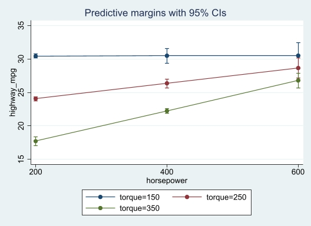

Regression Output 2

```stata
. margins,  at(horsepower=(200(200)600) torque=(150 250 350) year=2011)

Predictive margins                                       Number of obs = 4,591
Model VCE: OLS

Expression: Linear prediction, predict()
1._at: horsepower =  200
       torque     =  150
       year       = 2011
2._at: horsepower =  200
       torque     =  250
       year       = 2011
3._at: horsepower =  200
       torque     =  350
       year       = 2011
4._at: horsepower =  400
       torque     =  150
       year       = 2011
5._at: horsepower =  400
       torque     =  250
       year       = 2011
6._at: horsepower =  400
       torque     =  350
       year       = 2011
7._at: horsepower =  600
       torque     =  150
       year       = 2011
8._at: horsepower =  600
       torque     =  250
       year       = 2011
9._at: horsepower =  600
       torque     =  350
       year       = 2011

------------------------------------------------------------------------------
             |            Delta-method
             |     Margin   std. err.      t    P>|t|     [95% conf. interval]
-------------+----------------------------------------------------------------
         _at |
          1  |   30.42189   .1583814   192.08   0.000     30.11138    30.73239
          2  |   24.06309   .1533936   156.87   0.000     23.76237    24.36382
          3  |    17.7043   .3370353    52.53   0.000     17.04355    18.36505
          4  |   30.45992   .5421826    56.18   0.000     29.39698    31.52286
          5  |   26.34826   .3414242    77.17   0.000     25.67891    27.01762
          6  |    22.2366   .1683503   132.09   0.000     21.90656    22.56665
          7  |   30.49796   .9828305    31.03   0.000     28.57114    32.42478
          8  |   28.63343   .7619393    37.58   0.000     27.13966     30.1272
          9  |   26.76891   .5622544    47.61   0.000     25.66662     27.8712
------------------------------------------------------------------------------

. marginsplot, xtitle(horsepower) ytitle(highway_mpg)

Variables that uniquely identify margins: horsepower torque
```